# Machine Learning Project

Aysegul Sonmez

March 1, 2018

## Background

### Using devices such as Jawbone Up, Nike FuelBand, and Fitbit it is now possible to collect a large amount of data about personal activity relatively inexpensively. These type of devices are part of the quantified self movement - a group of enthusiasts who take measurements about themselves regularly to improve their health, to find patterns in their behavior, or because they are tech geeks. One thing that people regularly do is quantify how much of a particular activity they do, but they rarely quantify how well they do it. In this project, your goal will be to use data from accelerometers on the belt, forearm, arm, and dumbell of 6 participants. They were asked to perform barbell lifts correctly and incorrectly in 5 different ways. More information is available from the website here: http://web.archive.org/web/20161224072740/http:/groupware.les.inf.puc-rio.br/har (see the section on the Weight Lifting Exercise Dataset).

```r
library(knitr)
library(rpart.plot)
library(rpart.plot)
library(rattle)
library(randomForest)
library(corrplot)
library(caret)
library(rpart)
library(RColorBrewer)
library(gbm)
library(plyr)
library(rpart)

dt_training <- read.csv("pml-training.csv", na.strings=c("NA","#DIV/0!",""))
dt_testing <- read.csv("pml-testing.csv", na.strings=c("NA","#DIV/0!",""))
options <- names(dt_testing[,colSums(is.na(dt_testing)) == 0])[8:59]
```

# Only use features used in testing cases.

```r
dt_training <- dt_training[,c(options,"classe")]
dt_testing <- dt_testing[,c(options,"problem_id")]
dim(dt_training); dim(dt_testing);
```

```
## [1] 19622    53
```

```
## [1] 20 53
```

## Partitioning the Dataset

### Following the recommendation in the course Practical Machine Learning, we will split our data into a training data set (60% of the total cases) and a testing data set (40% of the total cases; the latter should not be confused with the data in the pml-testing.csv file). This will allow us to estimate the out of sample error of our predictor.

```r
library(caret)
set.seed(54321);

inTrain <- createDataPartition(dt_training$classe, p=0.6, list=FALSE)
training <- dt_training[inTrain,]
testing <- dt_training[-inTrain,]

dim(training); dim(testing);
```

```
## [1] 11776    53
```

```
## [1] 7846   53
```

## Building the Decision Tree Model

### Using Decision Tree, we shouldn’t expect the accuracy to be high. In fact, anything around 80% would be acceptable.

[figure not shown]

```r
set.seed(54321)
modFitDT <- rpart(classe ~ ., data = training, method="class", control = rpart.control(method = "cv", number = 10))
fancyRpartPlot(modFitDT)
```

## Predicting with the Decision Tree Model

```r
set.seed(54321)
prediction <- predict(modFitDT, testing, type = "class")
confusionMatrix(prediction, testing$classe)
```

```
## Confusion Matrix and Statistics
##
##           Reference
## Prediction    A    B    C    D    E
##          A 2047  317   41  147   65
##          B   44  736   62   35   61
##          C   60  185 1120  193  176
##          D   30  107   77  813   61
##          E   51  173   68   98 1079
##
## Overall Statistics
##
##                Accuracy : 0.7386
##                  95% CI : (0.7287, 0.7483)
##     No Information Rate : 0.2845
##     P-Value [Acc > NIR] : < 2.2e-16
##
##                   Kappa : 0.6676
##  Mcnemar's Test P-Value : < 2.2e-16
##
## Statistics by Class:
##
##                      Class: A Class: B Class: C Class: D Class: E
## Sensitivity            0.9171  0.48485   0.8187   0.6322   0.7483
## Specificity            0.8985  0.96808   0.9052   0.9581   0.9391
## Pos Pred Value         0.7822  0.78465   0.6459   0.7472   0.7345
## Neg Pred Value         0.9646  0.88680   0.9594   0.9300   0.9431
## Prevalence             0.2845  0.19347   0.1744   0.1639   0.1838
## Detection Rate         0.2609  0.09381   0.1427   0.1036   0.1375
## Detection Prevalence   0.3335  0.11955   0.2210   0.1387   0.1872
## Balanced Accuracy      0.9078  0.72646   0.8620   0.7951   0.8437
```

## Building the Random Forest Model

### Using random forest, the out of sample error should be small. The error will be estimated using the 40% testing sample. We should expect an error estimate of < 3%.

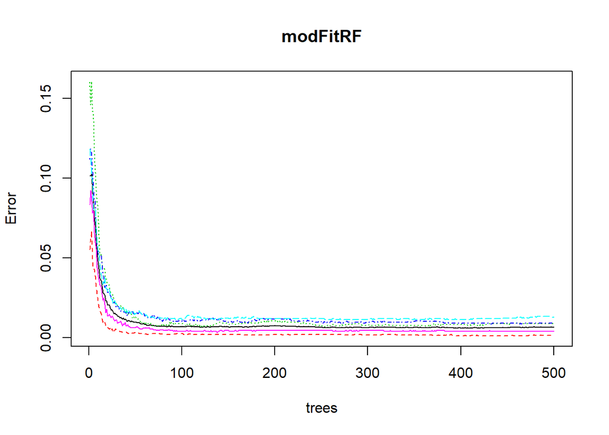

```r
set.seed(54321)
modFitRF <- randomForest(classe ~ ., data = training, method = "rf", importance = T, trControl = trainControl(method = "cv", classProbs=TRUE,savePredictions=TRUE,allowParallel=TRUE, number = 10))
plot(modFitRF)
```

##Predicting with the Random Forest Model

```r
prediction <- predict(modFitRF, testing, type = "class")
confusionMatrix(prediction, testing$classe)
```

```
## Confusion Matrix and Statistics
##
##           Reference
## Prediction    A    B    C    D    E
##          A 2225    9    0    0    0
##          B    7 1503    9    0    0
##          C    0    6 1359   17    0
##          D    0    0    0 1269    3
##          E    0    0    0    0 1439
##
## Overall Statistics
##
##                Accuracy : 0.9935
##                  95% CI : (0.9915, 0.9952)
##     No Information Rate : 0.2845
##     P-Value [Acc > NIR] : < 2.2e-16
##
##                   Kappa : 0.9918
##  Mcnemar's Test P-Value : NA
##
## Statistics by Class:
##
##                      Class: A Class: B Class: C Class: D Class: E
## Sensitivity            0.9969   0.9901   0.9934   0.9868   0.9979
## Specificity            0.9984   0.9975   0.9964   0.9995   1.0000
## Pos Pred Value         0.9960   0.9895   0.9834   0.9976   1.0000
## Neg Pred Value         0.9988   0.9976   0.9986   0.9974   0.9995
## Prevalence             0.2845   0.1935   0.1744   0.1639   0.1838
## Detection Rate         0.2836   0.1916   0.1732   0.1617   0.1834
## Detection Prevalence   0.2847   0.1936   0.1761   0.1621   0.1834
## Balanced Accuracy      0.9976   0.9938   0.9949   0.9932   0.9990
```

## Building the Boosting Model

```r
##install.packages("caret", dependencies = c("Depends","Suggests"))
##install.packages("lubridate")
library("caret")
library("lubridate")
modFitBoost <- train(classe ~ ., method = "gbm", data = training,
                     verbose = F,
                     trControl = trainControl(method = "cv", number = 10))

modFitBoost
```

```
## Stochastic Gradient Boosting
##
## 11776 samples
##    52 predictor
##     5 classes: 'A', 'B', 'C', 'D', 'E'
##
## No pre-processing
## Resampling: Cross-Validated (10 fold)
## Summary of sample sizes: 10599, 10598, 10598, 10599, 10600, 10597, ...
## Resampling results across tuning parameters:
##
##   interaction.depth  n.trees  Accuracy   Kappa
##   1                   50      0.7518718  0.6854187
##   1                  100      0.8199747  0.7721598
##   1                  150      0.8536873  0.8148744
##   2                   50      0.8560651  0.8176832
##   2                  100      0.9065053  0.8816813
##   2                  150      0.9307906  0.9124310
##   3                   50      0.8984370  0.8713841
##   3                  100      0.9419986  0.9266035
##   3                  150      0.9601732  0.9496176
##
## Tuning parameter 'shrinkage' was held constant at a value of 0.1
##
## Tuning parameter 'n.minobsinnode' was held constant at a value of 10
## Accuracy was used to select the optimal model using the largest value.
## The final values used for the model were n.trees = 150,
##  interaction.depth = 3, shrinkage = 0.1 and n.minobsinnode = 10.
```

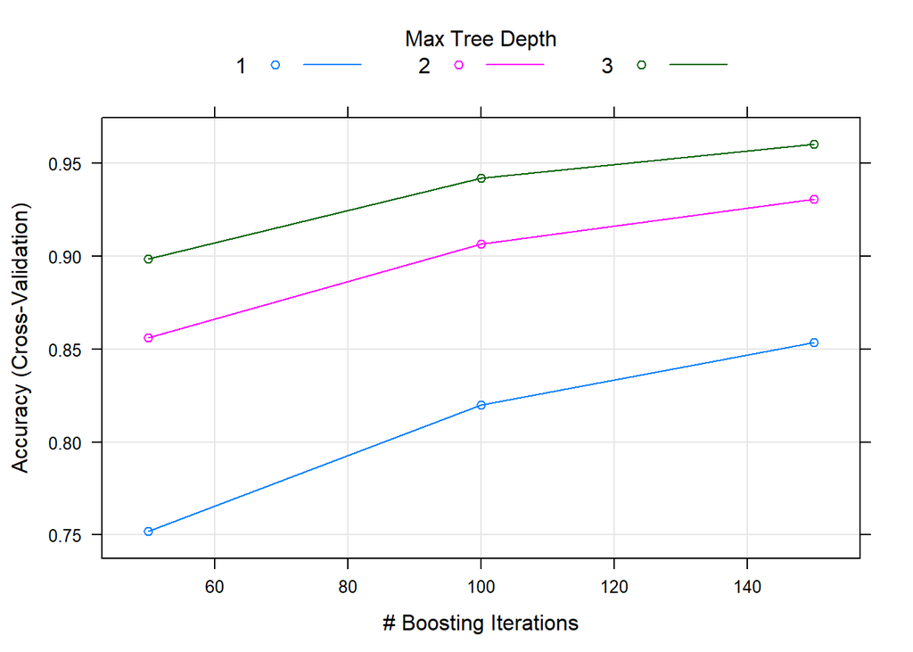

```r
plot(modFitBoost)
```

##Predicting with the Boosting Model

```r
prediction <- predict(modFitBoost, testing)
confusionMatrix(prediction, testing$classe)
```

```
## Confusion Matrix and Statistics
##
##           Reference
## Prediction    A    B    C    D    E
##          A 2196   47    0    1    5
##          B   31 1431   33    4    8
##          C    3   38 1316   48   12
##          D    2    0   16 1222   13
##          E    0    2    3   11 1404
##
## Overall Statistics
##
##                Accuracy : 0.9647
##                  95% CI : (0.9604, 0.9687)
##     No Information Rate : 0.2845
##     P-Value [Acc > NIR] : < 2.2e-16
##
##                   Kappa : 0.9553
##  Mcnemar's Test P-Value : 1.068e-05
##
## Statistics by Class:
##
##                      Class: A Class: B Class: C Class: D Class: E
## Sensitivity            0.9839   0.9427   0.9620   0.9502   0.9736
## Specificity            0.9906   0.9880   0.9844   0.9953   0.9975
## Pos Pred Value         0.9764   0.9496   0.9287   0.9753   0.9887
## Neg Pred Value         0.9936   0.9863   0.9919   0.9903   0.9941
## Prevalence             0.2845   0.1935   0.1744   0.1639   0.1838
## Detection Rate         0.2799   0.1824   0.1677   0.1557   0.1789
## Detection Prevalence   0.2866   0.1921   0.1806   0.1597   0.1810
## Balanced Accuracy      0.9872   0.9653   0.9732   0.9728   0.9856
```

## Predicting with the Testing Data (pml-testing.csv)

### Decision Tree Prediction

```r
predictionDT <- predict(modFitDT, dt_testing)
predictionDT
```

```
##             A           B           C          D           E
## 1  0.03521127 0.130281690 0.518779343 0.15551643 0.160211268
## 2  0.66047591 0.217063262 0.011027278 0.08183401 0.029599536
## 3  0.03301887 0.204402516 0.194968553 0.16981132 0.397798742
## 4  1.00000000 0.000000000 0.000000000 0.00000000 0.000000000
## 5  0.70308123 0.142857143 0.030812325 0.09803922 0.025210084
## 6  0.03521127 0.130281690 0.518779343 0.15551643 0.160211268
## 7  0.05241090 0.125786164 0.027253669 0.70649895 0.088050314
## 8  0.70308123 0.142857143 0.030812325 0.09803922 0.025210084
## 9  0.99487179 0.005128205 0.000000000 0.00000000 0.000000000
## 10 0.66047591 0.217063262 0.011027278 0.08183401 0.029599536
## 11 0.03521127 0.130281690 0.518779343 0.15551643 0.160211268
## 12 0.03301887 0.204402516 0.194968553 0.16981132 0.397798742
## 13 0.03521127 0.130281690 0.518779343 0.15551643 0.160211268
## 14 0.99487179 0.005128205 0.000000000 0.00000000 0.000000000
## 15 0.03301887 0.204402516 0.194968553 0.16981132 0.397798742
## 16 0.04545455 0.342245989 0.005347594 0.13368984 0.473262032
## 17 0.98314607 0.000000000 0.011235955 0.00000000 0.005617978
## 18 0.66047591 0.217063262 0.011027278 0.08183401 0.029599536
## 19 0.66047591 0.217063262 0.011027278 0.08183401 0.029599536
## 20 0.04678363 0.771929825 0.023391813 0.05847953 0.099415205
```

### Random Forest Prediction

```r
predictionRF <- predict(modFitRF, dt_testing)
predictionRF
```

```
##  1  2  3  4  5  6  7  8  9 10 11 12 13 14 15 16 17 18 19 20
##  B  A  B  A  A  E  D  B  A  A  B  C  B  A  E  E  A  B  B  B
## Levels: A B C D E
```

### Boosting Prediction

```r
predictionBoost <- predict(modFitBoost, dt_testing)
predictionBoost
```

```
##  [1] B A B A A E D B A A B C B A E E A B B B
## Levels: A B C D E
```

## Conclusion

### As can be seen from the confusion matrix the Random Forest model is very accurate, about 99%. Because of that we could expect nearly all of the submitted test cases to be correct. It turned out they were all correct.

```r
prediction_originaltesting_RF <- predict(modFitRF, testing, type = "class")
```